# D10_finder

Philip Sweet

2023-01-10

This Rmarkdown takes in raw CFU data with attached descriptors and determines the D10 value. To do so, the survival of each plate is determined relative to the mean of counts of respective biological replicate sham. A table of the mean survival is produced along with a graphical summary. A log model is then fit to predict the survival using the dose. The survival at 200Gy is then found. The D10 must be manually solved for. Finally, a summary plot is produced showing the mean survival percents, the fit line, and the D10.

CFU data should be a .csv with the following columns

1. BioRep: Biological Replicate, sham data denoted as “0” required per biological replicate. Catagorical.
2. Dose: Dose in Gy,numeric.
3. CFU: Counts per plate, numeric
4. TechRep: Not required, but advised. Numeric.

If data is correctly formated, the only change required is to solve for predicted d10 (Chunk 4) and to fine tune the final graph (Chunk 6)

```
## # A tibble: 12 × 3
## # Groups:   BioRep [3]
##    BioRep  Dose mean_surv
##    <chr>  <int>     <dbl>
##  1 A          0     100
##  2 A         70      69.7
##  3 A        100      67.9
##  4 A        170      36.3
##  5 B          0     100
##  6 B         70      79.4
##  7 B        100      56.6
##  8 B        170      41.9
##  9 C          0     100
## 10 C         70      79.9
## 11 C        100      70.9
## 12 C        170      39.6
```

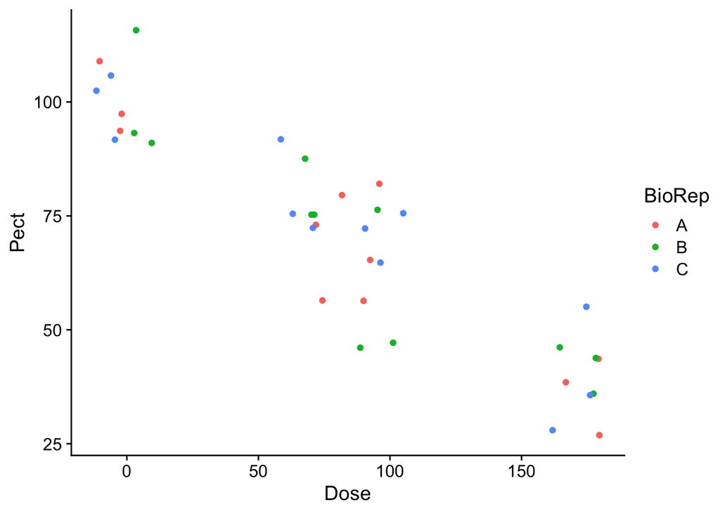

```r
data %>%
  ggplot(aes(x = Dose, y = Pect, color = BioRep)) +
  geom_jitter() +
  theme_cowplot()
```

```r
lm(log(data$Pect)~data$Dose) -> ab_model

 summary(ab_model)
```

```
##
## Call:
## lm(formula = log(data$Pect) ~ data$Dose)
##
## Residuals:
##      Min       1Q   Median       3Q      Max
## -0.41290 -0.12404  0.02721  0.09496  0.30831
##
## Coefficients:
##              Estimate Std. Error t value Pr(>|t|)
## (Intercept)  4.660678   0.051798   89.98  < 2e-16 ***
## data$Dose   -0.005616   0.000495  -11.35 4.17e-13 ***
## ---
## Signif. codes:  0 '***' 0.001 '**' 0.01 '*' 0.05 '.' 0.1 ' ' 1
##
## Residual standard error: 0.1813 on 34 degrees of freedom
## Multiple R-squared:  0.7911, Adjusted R-squared:  0.7849
## F-statistic: 128.7 on 1 and 34 DF,  p-value: 4.174e-13
```

Input model outputs into the variables below to calculate survival at 200Gy.

```
## [1] 34.37707
```

```
## [1] 9.991873
```

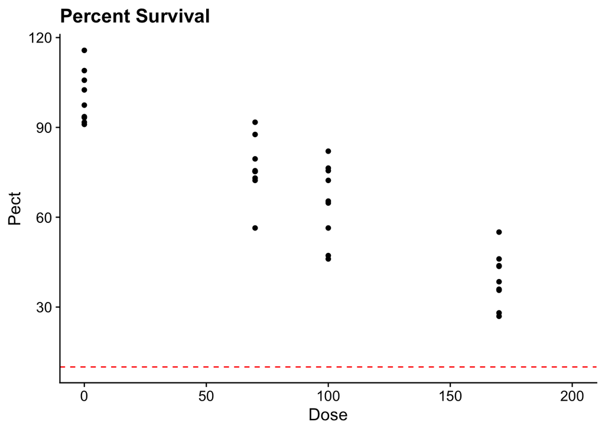

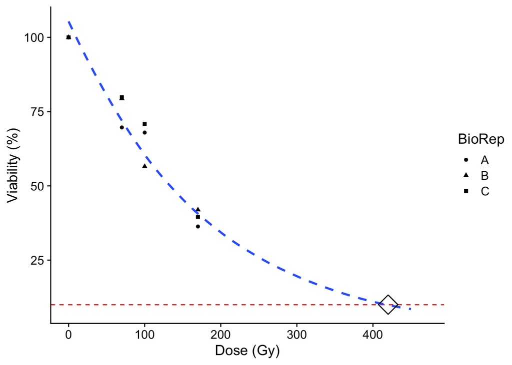